# 第10回 単回帰・最小二乗法・決定係数

経済データ入門

第10回

単回帰・最小二乗法・決定係数

点の雲に 1 本の線を引き、二乗和で選び、R² で当たり具合を測る

経済データ入門

第10回 — Topic01

単回帰

点の雲を、1 本の線で要約する

## 前回の振り返り

前回のポイント 第9回「散布図・共分散・相関係数」

Q: 5 人のバイト日数と自習時間は、どんな関係だったか

- **散布図**：5 つの点が、左上から右下へ下がって並ぶ
- **相関係数**：−0.894。−1 にかなり近い右下がり
- **読み方**：一緒に動く度合い。原因とは別の話

今日は、その点の雲に 1 本の線を引く

## この回の道のりと「5人」シート

1

単回帰

演習 10-1

傾きを替えた予測値

2

最小二乗法

演習 10-2

36 年の二乗和

3

分析ツール

演習 10-3

失業率 5% の見込み

4

決定係数

演習 10-4

期間を変えた決定係数

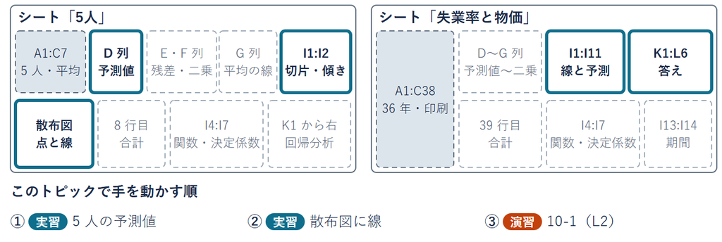

置き場は lec10-exercise.xlsx の「5人」と  
「失業率と物価」。2 枚のシートで回を通す

## 相関係数で言えない量

「来月からバイトを 1 日増やす。自習は何時間くらい減りそう？」  
この問いに、相関係数 −0.894 は答えられるか

- **相関係数**：右下がりの強さを言う。どれだけ減るかは言わない
- **知りたいこと**：x が 1 増えると、y がどれだけ変わるかという量
- **そこで**：相関係数は直線への近さを測った。  
  だから点の雲に直線を引き、量は傾きで読む

## 5 人の点に引く 1 本の線

[figure not shown]

まず仮に 1 本引く：12 − 2x（どう選ぶかは次のトピック）  
× が x ＝ 1〜5 の見込み ŷ（ワイハット）、丸が実際の値 y

## 予測値と実際の値

用語

**予測値 ŷ**：線の式から出した y の見込み（ワイハット）

**実際の値 y**：表に書いてある値

| 名前 | バイト日数 x | 実際の値 y | 予測値 ŷ ＝ 12 − 2x |
| --- | --- | --- | --- |
| A | 1 | 9 | 10 |
| B | 2 | 10 | 8 |
| C | 3 | 6 | 6 |
| D | 4 | 2 | 4 |
| E | 5 | 3 | 2 |

**サンプルデータ**：架空の 5 人（lec10-exercise.xlsx「5人」の A1:C6）

## 単回帰

**単回帰：点の雲を、1 本の線で要約する**

定義

$$\textbf{予測値}\ \hat{y} = \textbf{切片} + \textbf{傾き} \times x$$

今回は

$\hat{y}$

$= 12 - 2x$

5 人の線

「単」は、自習時間を説明するのに使うもの  
（バイト日数 x）が 1 つだけ、という意味

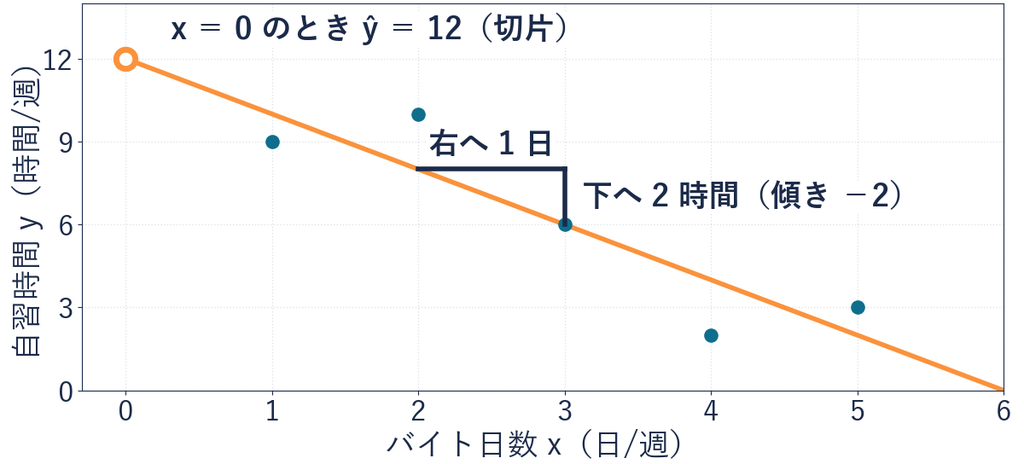

## 傾きと切片

用語

**傾き**：x が 1 増えると、ŷ がいくつ変わるか

**切片**：x が 0 のときの ŷ

- **傾き −2**：バイトが 1 日多い人は、自習の見込みが 2 時間短い
- **比べ合い**：人どうしを比べた量。  
  1 日増やせば 2 時間減る、とまでは言えない
- **切片 12**：バイト 0 日なら自習 12 時間の見込み  
  （5 人に 0 日の人はいない）
- **単位をつける**：裸の −2 ではなく、1 日あたり −2 時間

## 傾きの読み方

[figure not shown]

1 日右へ進むと、線は 2 時間下がる。x ＝ 0 の高さが切片 12

## 5 人の予測値の列

1. **置く**：I1 に 12、I2 に −2  
   I3 は次のトピックで使う  
   （触らない）
2. **式**：D2 に  
   `=$I$1+$I$2*B2` → 10
3. **コピー**：D6 までフィル  
   → 10, 8, 6, 4, 2

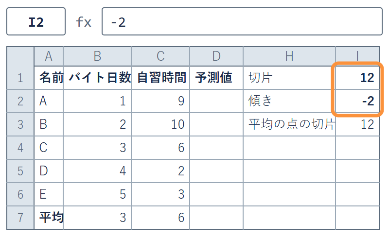

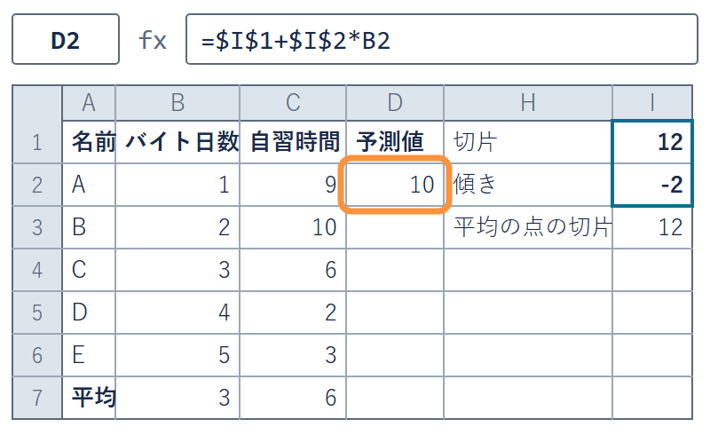

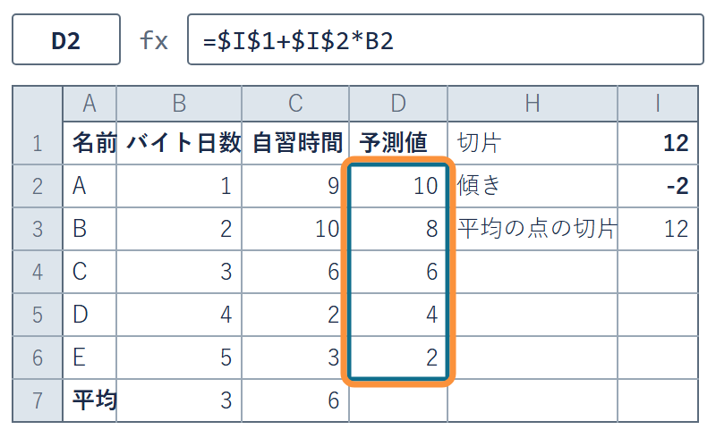

`$` は F4（Mac では ⌘ + T）。式に 12 や −2 を書かず、セルを指す

✋ 動画を止めて ①〜③ を進め、D 列がそろったら再生に戻る

## 散布図に重ねる線

1. **散布図**：B1:C6 で前の回と  
   同じ散布図  
   枠は A12 から下へ動かす
2. **追加**：右クリック → データの  
   選択 → 追加  
   X の値に B2:B6、  
   Y の値は中を消して D2:D6
3. **線**：予測値を右クリック →  
   データ系列の書式設定  
   → 線（単色）・マーカーなし

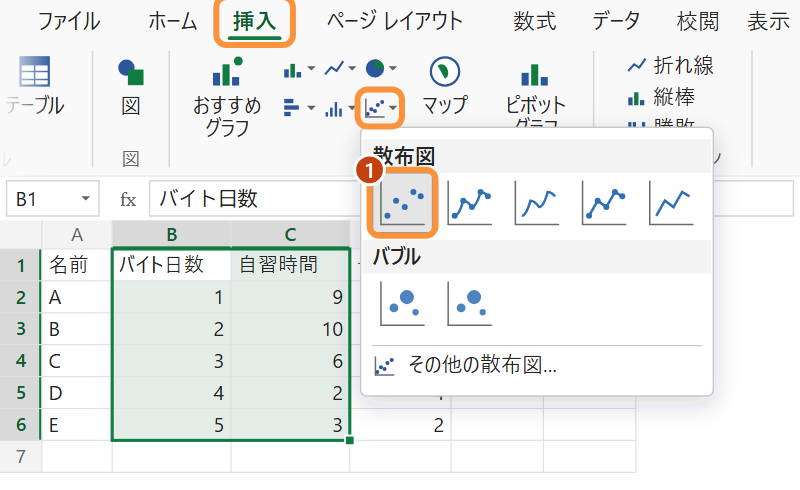

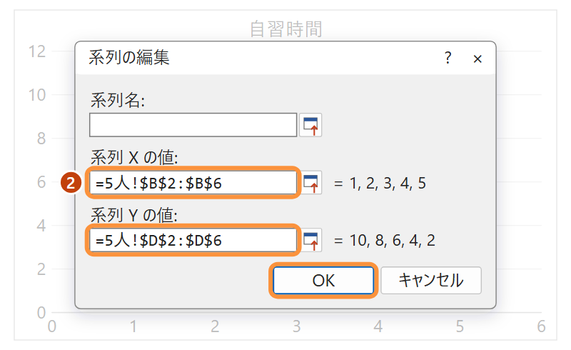

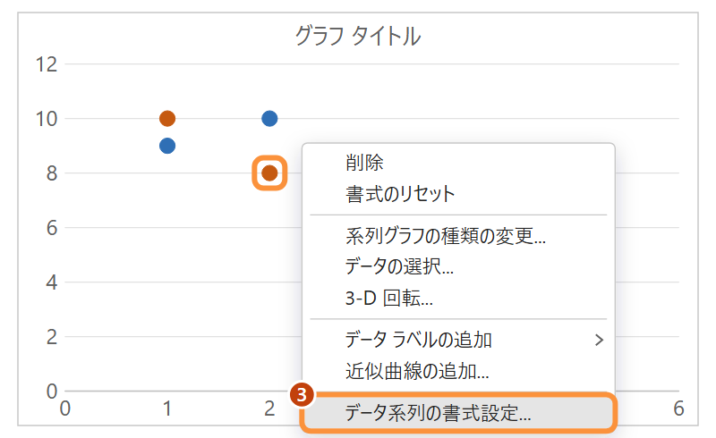

Mac も同じ右クリックのメニューから

✋ 動画を止めて ①〜③ を進め、線が重なったら再生に戻る

## Q&A 予測値の列

Q1 D 列が 3 行目から崩れた

切片と傾きのセルに `$` が無い。D3 が **`=$I$1+$I$2*B3`** かを見る

Q2 式に 12 と −2 を直接書いてはいけないか

線を替えるたびに式を全部直すことになる。  
**セルに置けば 1 か所**で済む

Q3 点が線の上に乗らない

乗らないのがふつう。そのずれを**次のトピック**で数にする

## 36 年に引く例の線

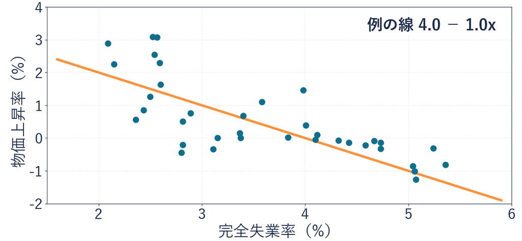

**実データ**：前に出てきた 36 年（総務省統計局）  
4.0 − 1.0x は目で引いた仮の線。いちばん良い線ではない

## 傾きの単位

- **1 行**：ある年。x は完全失業率、y は物価上昇率（どちらも %）
- **傾き −1.0**：目で引いたこの線では、失業率が 1 ポイント高い年は、  
  物価上昇率を 1 ポイント低く見込む
- **ポイント**：% どうしの差の単位（4% から 5% で 1 ポイント）  
  4% の 1% 増しなら 4.04%（差は 0.04 ポイント）
- **切片 4.0**：失業率 0% の年は無い。この線の高さを決める数として読む

「高い年は低い」と年どうしで比べて言う。原因とまでは言わない

## 演習 10-1 傾きを替えた予測値

演習 10-1

目で引いた線 4.0 − 1.0x の傾きを −0.5 にする  
失業率 4.0% の予測値はどうなるか

1. **予想**：傾きを −0.5（ゆるく）にすると、予測は上がる・下がる・同じ
2. **線**：「失業率と物価」の I1 に 4.0、I2 に −1.0
3. **予測**：I9 に 4.0、I10 に `=I1+I2*I9` → 0.0
4. **替える**：I2 を −0.5 に打ち替えて、I10 を見る
5. **答え**：I10 の数を L2 に数字で打つ（`=I10` と入れない）

線だけで計算する。36 年の点（A1:C37）は、まだ使わない

## 何本も引ける線

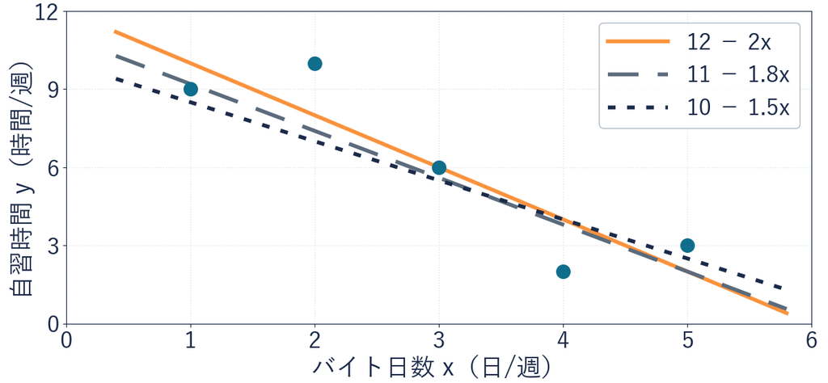

線を替えると、同じ失業率でも予測が変わる  
5 人でも、11 − 1.8x や 10 − 1.5x が点の近くを通る

## まとめ

- **単回帰**：点の雲を 1 本の線 ŷ ＝ 切片 ＋ 傾き × x で要約する
- **予測値 ŷ**：線の式から出した見込み。実際の値 y とは別
- **傾き**：単位つきで読む。5 人は 1 日あたり −2 時間
- **36 年**：傾きはポイントで読む。  
  失業率が高い年ほど物価上昇率が低い、と年どうしを比べて言う

線を引けば量で言えた。でも線は何本でも引ける。どの線を選ぶか  
これを次のトピックで見る

経済データ入門

第10回 — Topic02

最小二乗法

線を引く基準を、どう決める？

## この回の道のりと「5人」シート

1

単回帰

演習 10-1

傾きを替えた予測値

2

最小二乗法

演習 10-2

36 年の二乗和

3

分析ツール

演習 10-3

失業率 5% の見込み

4

決定係数

演習 10-4

期間を変えた決定係数

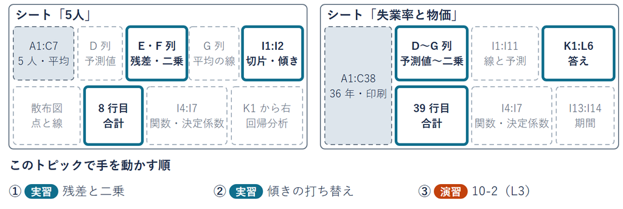

置き場は「5人」の E・F 列と 8 行目、I1。  
「失業率と物価」の D〜F 列と 39 行目

## 線を選ぶ基準

12 − 2x の線は引けた。でも 11 − 1.8x も点の近くを通る  
目で選ぶと、人によって違う線になる

- **知りたいこと**：誰が選んでも同じ線になる基準
- **そこで**：点と線のずれを数にして、ずれの小さい線を選ぶ
- **ずれの測り方**：当てたいのは自習時間 y なので  
  y の向き（縦）に、点から線まで測る

## 残差

用語

**残差**：実際の y − 予測値 ŷ（点から線へ下ろす縦の長さ）

- **符号**：点が線より上ならプラス、下ならマイナス
- **1 人に 1 つ**：5 人なら残差は 5 つ
- **0 に近いほど**：その人の点に、線が近い（マイナスでも同じ）
- **呼び方**：前のページの「ずれ」は、この残差のこと

## 最小二乗法の手順

手順

STEP 1線の式で予測値 ŷ を出す

STEP 2残差 ＝ y − ŷ を出す

STEP 3残差を二乗する

STEP 4二乗を全部足す（二乗和）

二乗和がいちばん小さい線を選ぶ。なぜ二乗するかは、このあと

## 平均の水平線の残差

[figure not shown]

平均の水平線 ŷ ＝ 6。どの人にも 6 時間を見込む

## たしかめ 残差の和

平均の点（3, 6）＝ x の平均 3 と y の平均 6。  
前の回の十字が交わる点  
（今回はたまたま C と同じ位置）。この点を通る線を、  
傾きを変えて何本も引く  
残差の和は、どうなるか

**1 点に沿う線ほど 0 に近い**

**2 どの線でも同じ**

1 つ決めてから先へ。答えは、次のページで出す

## 平均の点を通る 4 本の線

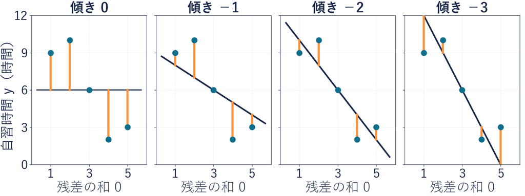

どの線でも残差の和は 0。たしかめの答えは 2 番

## よくある失敗 残差の和による選択

**残差を足して選ぶ**  
上のずれと下のずれが  
打ち消し合う  
平均の点を通る線  
なら、どれも 0  
和では 1 本に選べない

**二乗して足す**  
上も下もプラスになる  
大きな残差を重く数える  
（2 は 4、3 は 9）

分散と同じく、二乗してから足す

## 二乗したずれ

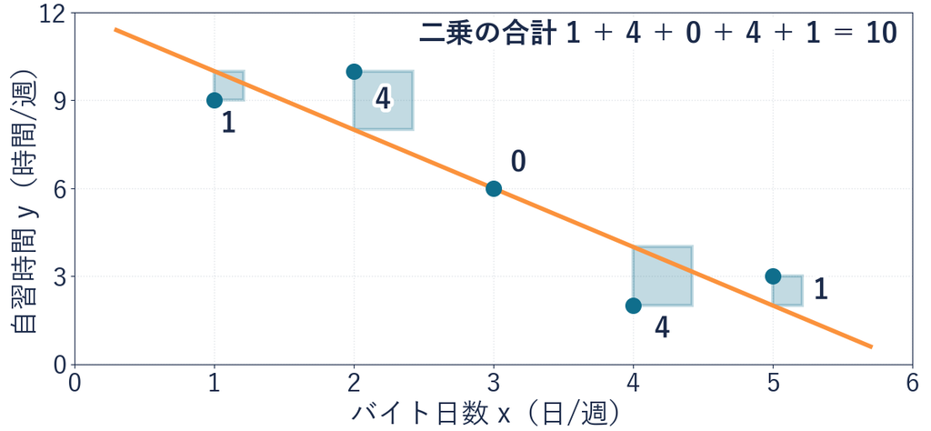

線 12 − 2x の残差 −1, 2, 0, −2, 1 を二乗すると  
1, 4, 0, 4, 1。二乗和は 10

## 二乗和の U 字

[figure not shown]

傾きを 0, −1, −2, −3, −4 と動かすと（図では右から左へ）  
二乗和は 50, 20, 10, 20, 50。底は −2  
どの傾きでも、上下にずらすと増える（13 − 2x も 11 − 2x も 15）  
だから平均の点を通る線で、傾きだけ探す

## 最小二乗法

**最小二乗法：ずれを二乗して足し、いちばん小さい線を選ぶ**

定義

$$\textbf{最小二乗の線} = \textbf{残差の二乗和がいちばん小さい線}$$

今回は

$\hat{y}$

$= 12 - 2x$

二乗和 10

ずれの和ではなく、二乗の和で選ぶ。そう決めた選び方

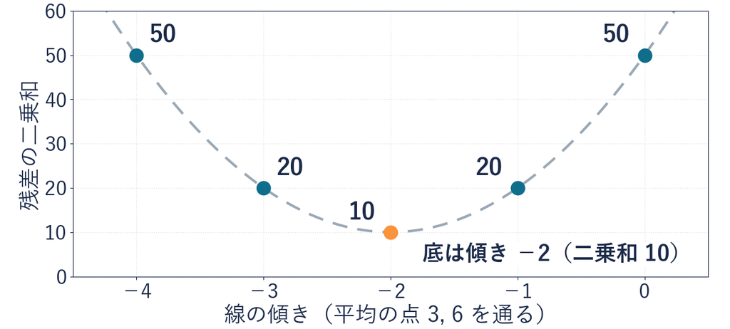

## 5 人の残差と二乗の列

1. **残差**：E2 に `=C2-D2`  
   → E6 までフィル
2. **二乗**：F2 に `=E2*E2`  
   → F6 までフィル
3. **合計**：E8 に `=SUM(E2:E6)`  
   F8 に `=SUM(F2:F6)` → 0 と 10

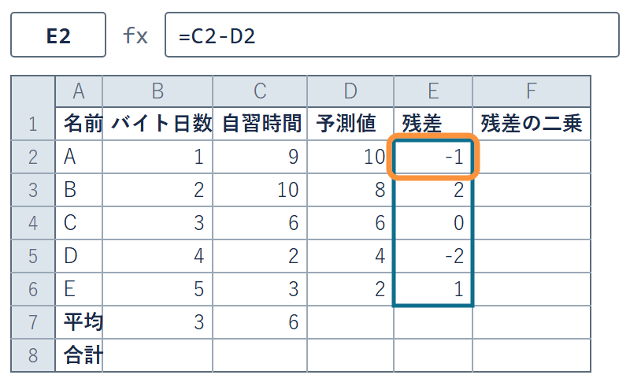

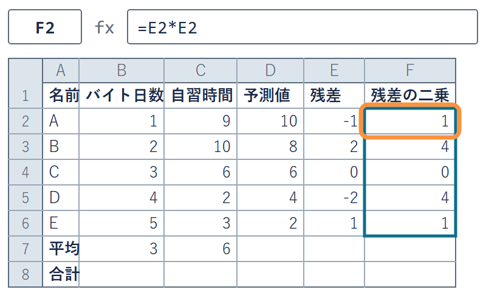

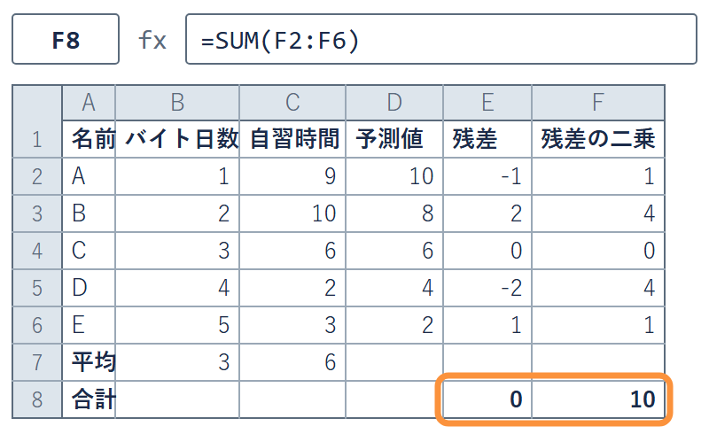

✋ 動画を止めて ①〜③ を進め、F8 が 10 なら再生に戻る

## 傾きの打ち替え

1. **切片をつなぐ**：I1 に `=I3`  
   I3 は平均の点を通る切片
2. **傾き 0**：I2 に 0  
   → F8 は 50
3. **打ち替え**：I2 を −1, −2, −3  
   → F8 は 20, 10, 20。  
   最後に I2 を −2 に戻す

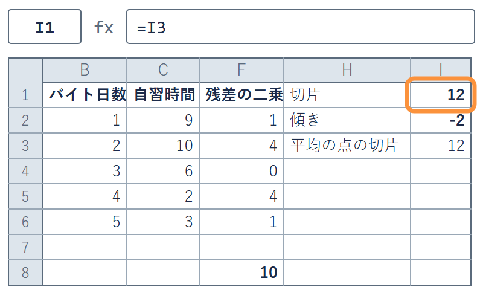

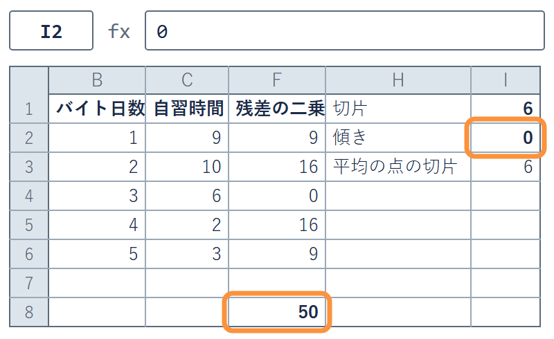

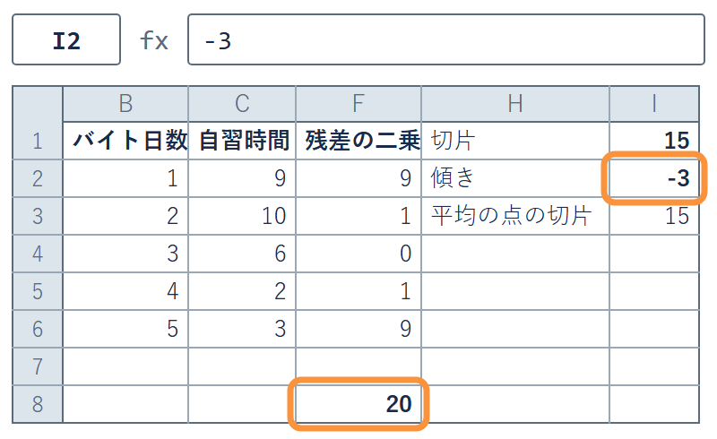

線はいつも平均の点（3, 6）を通る。散布図を作った人は、その線も回る

✋ 動画を止めて ①〜③ を進め、U 字の数が出たら再生に戻る

## Q&A 残差と二乗和

Q1 E8 が 0 になった。間違いか

間違いではない。**平均の点を通る線**なら、残差の和はいつも 0

Q2 F 列が −2, 4, 0, −4, 2 になった

✗ `=E2*2` は 2 倍。二乗は **`=E2*E2`**（同じ数を掛ける）

Q3 傾きを替えたら E8 が 0 でなくなった

I1 が 12 のまま。**I1 を `=I3`** にして、平均の点を通す

## 36 年の二乗和

今度は前に出てきた 36 年で、同じ二乗和を比べる

| 線 | 二乗和 |
| --- | --- |
| 平均の水平線（どの年も 36 年の平均 0.54%） | 48.48 |
| 例の線 4.0 − 1.0x | 23.35 |
| いちばん小さい線 | ？ |

点は 36 個。底を手で探すのは大変なので、まず実験室で探す

## デモ：最小二乗の実験室

定義

残差 ＝ 実際の y − 予測値 ŷ  
残差を二乗して足した二乗和が、いちばん小さい線を選ぶ

- **何を見るか**：傾きを動かすと、残差の和は 0 のまま、二乗和だけが動く
- **図の意味**：左は散布図と線と残差、右上は傾きと二乗和の U 字
- **操作**：傾きのつまみ・タブ ①②・答え合わせ・元に戻す

ミッション ② 36 年で、  
例の線より二乗和が小さくなるかを予想してから底を探す

※ 次のスライドへ進むときは、デモの枠の外を一度クリックしてから ← → キーを押す

[interactive chart not shown]

## 36 年の最小二乗の線

[figure not shown]

二乗和 22.13 がいちばん小さい線

## 演習 10-2 36 年の二乗和

演習 10-2

実験室で見つけた線 3.614 − 0.859x で  
二乗和を自分のシートで出す

1. **列**：D2 に `=$I$1+$I$2*B2`、E2 に `=C2-D2`、F2 に `=E2*E2`  
   → D2:F2 を 37 行目までフィル
2. **二乗和**：F39 に `=SUM(F2:F37)`
3. **比べる**：I1 に 4.0、I2 に −1.0 なら 23.35 になるか
4. **答え**：I1 を 3.614、I2 を −0.859 にした F39 の数を  
   L3 に数字で打つ（小数第 2 位まで）

**実データ**：「失業率と物価」の A1:C37（36 年）。実験室と同じ数か

## まとめ

- **残差**：実際の y − 予測値 ŷ。平均の点を通る線なら和は 0
- **二乗する**：上と下が打ち消し合わない。大きな残差を重く数える
- **最小二乗法**：二乗和がいちばん小さい線を選ぶ（5 人は 12 − 2x）
- **36 年**：線は 3.614 − 0.859x。二乗和 22.13

選び方は決まった。でも、底を手で探すのは大変  
これを次のトピックで見る

経済データ入門

第10回 — Topic03

回帰分析と分析ツール

Excel で回帰分析

## この回の道のりと「5人」シート

1

単回帰

演習 10-1

傾きを替えた予測値

2

最小二乗法

演習 10-2

36 年の二乗和

3

分析ツール

演習 10-3

失業率 5% の見込み

4

決定係数

演習 10-4

期間を変えた決定係数

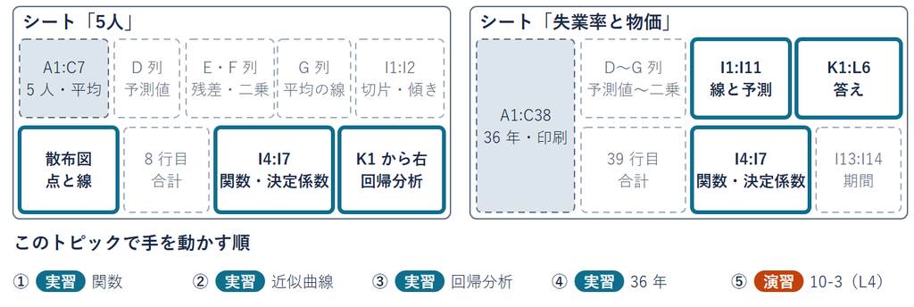

置き場は「5人」の I4・I5・散布図・K1 から右、  
「失業率と物価」の I4・I5・I9・I11

## 線を引く 3 つの道具

5 人なら、傾きを打ち替えて底が見つかった  
36 年では手で探すのは大変。Excel に一度で引かせる

**関数**  
傾きと切片の数  
そのまま予測の式  
に使える

**グラフ**  
近似曲線と数式  
点と線を目で  
確かめる

**分析ツール**  
回帰分析の表  
当てはまりも  
1 枚に並ぶ

## SLOPE と INTERCEPT

用語

**SLOPE**：最小二乗の線の傾きをセルに出す関数

**INTERCEPT**：最小二乗の線の切片をセルに出す関数

- **引数**：`=SLOPE(y の範囲, x の範囲)`。y が先
- **CORREL との違い**：CORREL は順を入れ替えても  
  同じ数。SLOPE は別の線
- **今回は**：−2 と 12。U 字の底と同じ線

## 関数による傾きと切片

1. **傾き**：I4 に  
   `=SLOPE(C2:C6,B2:B6)` → −2
2. **切片**：I5 に  
   `=INTERCEPT(C2:C6,B2:B6)` → 12
3. **見る**：I1・I2 と同じ 12 と −2  
   U 字の底と同じ線

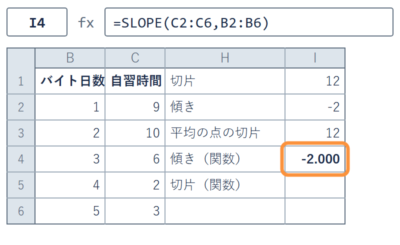

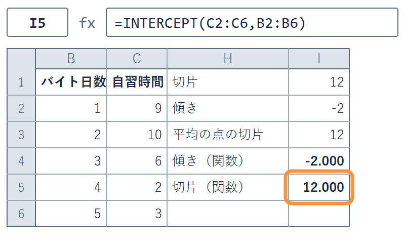

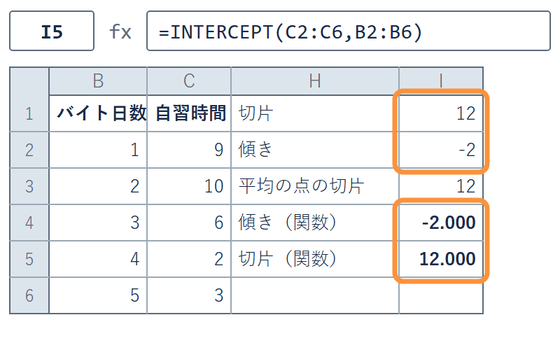

✋ 動画を止めて ①〜③ を進め、−2 と 12 が出たら再生に戻る

## よくある失敗 SLOPE の引数の順

**x を先に書く**  
`=SLOPE(B2:B6,C2:C6)`  
→ −0.4（別の線）  
自習が 1 時間多い人は  
バイトが 0.4 日少ない

**y を先に書く**  
`=SLOPE(C2:C6,B2:B6)`  
→ −2（U 字の底と同じ線）

逆にしてもエラーは出ない。確かめは、T2 で見つけた傾き −2 と同じ数か

## 近似曲線の数式

1. **右クリック**：自習時間の点  
   （予測値の線ではない）を  
   右クリック → 近似曲線の追加
2. **選ぶ**：線形近似と  
   「グラフに数式を表示する」
3. **見る**：y = -2x + 12 が出れば OK  
   点線が予測値の線と重なる

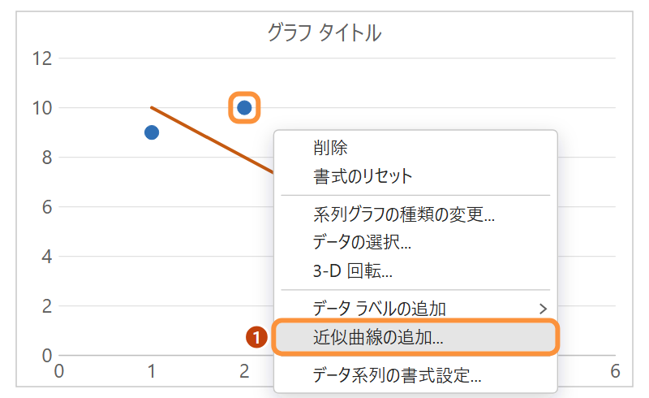

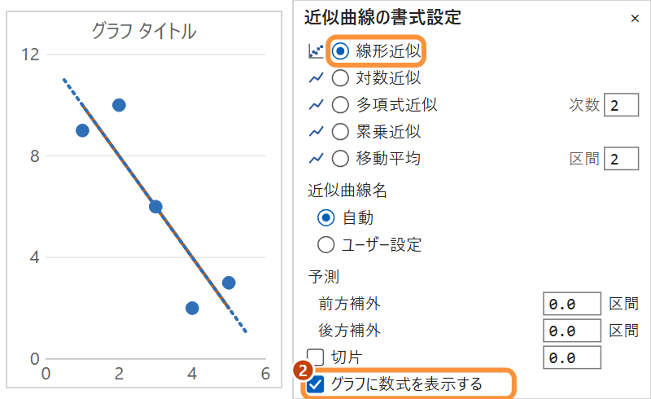

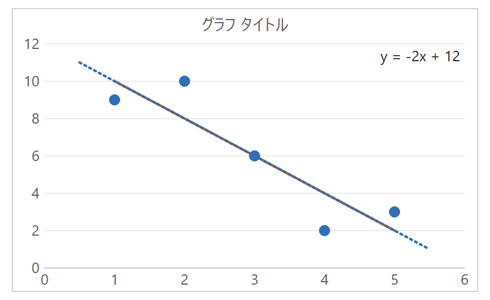

Mac も点を右クリック → 近似曲線の追加

✋ 動画を止めて ①〜③ を進め、数式が出たら再生に戻る

## 分析ツールの回帰分析

入口は「データ」タブの「データ分析」  
無ければ、ガイダンス資料を見て分析ツールを有効化

1. **入力 Y 範囲**：説明されるほう  
   自習時間 C1:C6
2. **入力 X 範囲**：説明に使うほう  
   バイト日数 B1:B6
3. **ラベル**：1 行目の見出しを  
   名前に使うのでチェック
4. **出力先**：「一覧の出力先」の丸  
   右の枠に K1

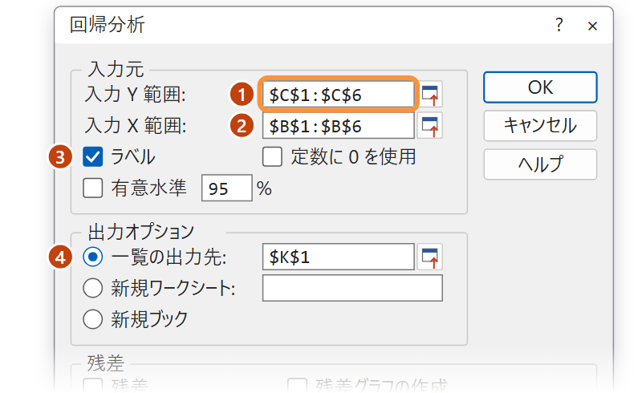

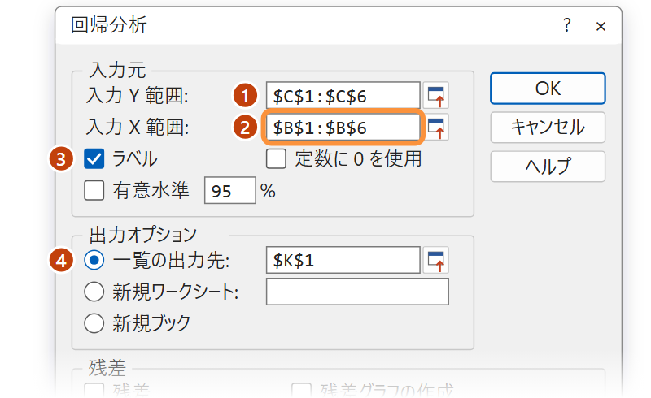

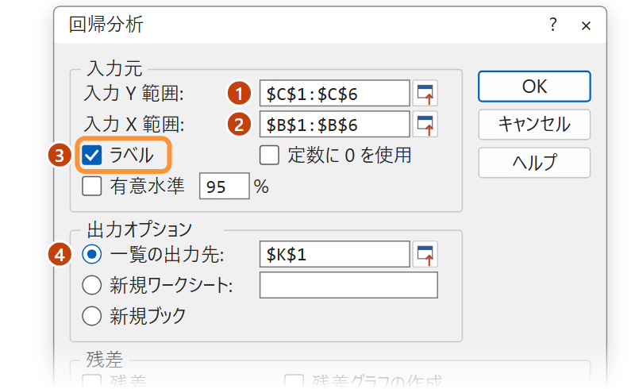

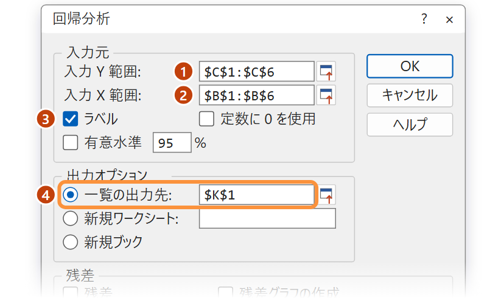